# 최저임금 인상이 물가에 미치는 영향

19_신정민 25_이예은

**데이터 선정이유**

- 최근 소비자물가가 지속적인 상승세를 보이고 있다. 밥상물가뿐만 아니라 서비스물가, 외식물가가 줄줄이 상승하면서 전반적인 물가상승이 나타나고 있다. 소비자물가 상승률은 지난해 10월 이후 12개월 연속으로 1%씩 상승하고 있었고 지난달인 2018년 10월에는 13개월만에 가장 높은 상승률인 2%로 상승했다.

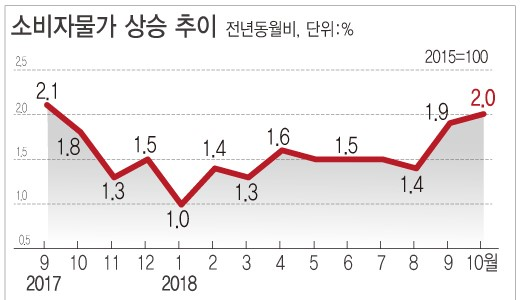

- 물가 인상의 주된 요인으로 뽑는 것이 최저임금 인상이다. 올해, 2018년 최저임금은 7530원으로 2017년에 6470원이었던 것과 비교하면 무려 16.4%나 상승하였다. 16.4%라는 상승률은 17년만에 가장 큰 폭으로 상승한 것이다. 2019년도 올해보다 10.9% 인상된 8350원으로 확정된 상황이다.

[figure not shown]

- 서민들이 물가인상을 바로 체감하는 외식업계를 예로 들자면 최저임금 인상으로 인한 인건비 부담으로 인해 가격을 올렸다고 주장한다. 음식의 가격뿐만 아니라 배달료까지 받게 되면서 소비자들의 부담이 가중되었다. 이와 같이 최저임금 인상 후 물가의 변화를 기사를 통해 접하거나 직접 경험하면서 최저임금 인상이 물가 상승에 주는 영향이 크다는 생각을 가지게 되었다.
- 하지만 전문가들은 이에 대해 다른 의견을 보인다. 최저임금 인상이 물가상승의 주범이 아니라는 것이다. 2015년 강승복 한국노동연구원 전문위원이 발표한 <최저임금 인상이 물가에 미치는 영향> 논문을 보면 최저임금이 10% 오르면 물가는 최대로 0.4%까지만 오른다고 한다. 또한 한국소비자단체협의회와 물가감시센터가 개최한 ‘최저임금 인상에 따른 외식물가 안정화’를 위한 토론회의 결론도 최근 물가상승에 대해 단순히 최저임금의 인상을 주된 요인으로 볼 것이 아니라 그 밖의 다른 요인들의 영향에도 기인하는 복합적인 현상임을 공통적으로 주장했다.

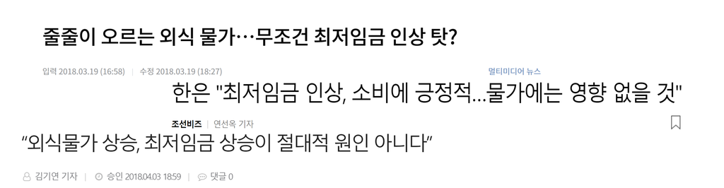

- 따라서 이번 분석을 통해 최저임금 인상이 물가인상에 어느정도 영향을 미치는지 살펴보고자 한다. 더 나아가 최저임금 외에 다른 요인들도 물가와 어느정도의 상관관계가 있는지 알아보고자 한다.
- 이번 분석에서 필요한 배경이론은 단순회귀분석이다. 단순회귀분석이란 한 개의 종속변수 Y와 한 개의 독립변수 X사이의 선형관계를 파악하거나, 한 개의 독립변수의 일정한 값에 대응되는 종속변수의 값을 예측하기 위한 방법이다.

**변수와 모형설정**

```
 2009년 1분기부터 2018년 2분기까지 분기별 전동기대비증감률데이터를 이용하여 우리나라의 최저임금 인상이 소비자 물가에 미치는 영향을 분석하려 한다.
 소비자 물가지수 증감의 요인으로는 통화량, 소득, 소비성향, 인플레이션 기대심리, 생산기술 및 설비투자, 자연조건, 수출입, 환율등 여러 가지가 있다.
 본 분석에서는 종속변수를 소비자물가지수(CPI)로 설정하고, 독립변수로 최저임금,임대료와 거시변수 대표로 gdp deflator를 설정하였다.
```

```r
#패키지 불러들이기
library(readxl)
library(dplyr)
library(ggplot2)
library(tidyr)
library(lattice)
```

```r
#데이터 불러들이기
price <- read_xlsx("price inf.xlsx")
rent <- read_xlsx("rent inf.xlsx")
wage <- read_xlsx("wage_inf.xlsx")
gdp <- read_xlsx("gdp deflator inf.xlsx")
```

데이터에 모든 분기가 한열씩 존재하고 있으므로 `gather()`함수를 이용해 새로운 **quarter**열을 만들어 분기를 모아준다.

```r
wage1 <-wage %>% gather("quarter", "wage", `2009년1분기`:`2018년2분기`)
gdp1 <-gdp %>% gather("quarter", "gdp", `2009 1/4`:`2018 2/4`)
rent1 <- rent %>% gather("quarter","rent",`2009년1분기`:`2018년3분기`)
price1 <- price %>% gather("quarter","price",`2009 1/4`:`2018 2/4`)
```

다음으로 `join()`함수를 이용해 모든 독립변수와 종속변수를 하나의 데이터 프레임으로 만든다. 이 과정에서 **quarter**열의 속성 값 표시형식을 통일시킨다.

```r
rent1<-rent1 %>%
  filter(`지 역`=="증감률") %>%
  select(quarter,rent)

dat1<-inner_join(price1 ,gdp1, by="quarter")
dat1 <- dplyr::select(dat1, quarter,price,gdp)

dat2 <- inner_join(rent1,wage1,by="quarter")
dat2 <- dat2 %>% mutate(quarter = gsub("년"," ",dat2$quarter))
dat2 <- dat2 %>% mutate(quarter = gsub("분기","/4",dat2$quarter))

dat2 <- dplyr::select(dat2, quarter,rent,wage)

dat3 <- left_join(dat1,dat2,by="quarter")
dat3
```

```
## # A tibble: 38 x 5
##     quarter price   gdp       rent  wage
##       <chr> <dbl> <dbl>      <dbl> <dbl>
##  1 2009 1/4   3.9   4.0  0.5474453  6.10
##  2 2009 2/4   2.8   4.0  0.9074410  6.10
##  3 2009 3/4   2.0   3.7  0.1798561  6.10
##  4 2009 4/4   2.4   2.5  0.8976661  6.10
##  5 2010 1/4   3.0   3.2  1.6014235  2.75
##  6 2010 2/4   2.7   3.1  5.2539405  2.75
##  7 2010 3/4   2.9   3.0 -0.1663894  2.75
##  8 2010 4/4   3.2   3.4  0.5000000  2.75
##  9 2011 1/4   3.8   2.0  0.9950249  5.10
## 10 2011 2/4   4.0   1.0  0.8210181  5.10
## # ... with 28 more rows
```

```r
#데이터 살펴보기
glimpse(dat3)
```

```
## Observations: 38
## Variables: 5
## $ quarter <chr> "2009 1/4", "2009 2/4", "2009 3/4", "2009 4/4", "2010 ...
## $ price   <dbl> 3.9, 2.8, 2.0, 2.4, 3.0, 2.7, 2.9, 3.2, 3.8, 4.0, 4.3,...
## $ gdp     <dbl> 4.0, 4.0, 3.7, 2.5, 3.2, 3.1, 3.0, 3.4, 2.0, 1.0, 1.4,...
## $ rent    <dbl> 0.5474453, 0.9074410, 0.1798561, 0.8976661, 1.6014235,...
## $ wage    <dbl> 6.10, 6.10, 6.10, 6.10, 2.75, 2.75, 2.75, 2.75, 5.10, ...
```

```r
summary(dat3)
```

```
##    quarter              price            gdp              rent
##  Length:38          Min.   :0.600   Min.   :-0.300   Min.   :-10.4704
##  Class :character   1st Qu.:1.125   1st Qu.: 1.000   1st Qu.:  0.0000
##  Mode  :character   Median :1.600   Median : 1.900   Median :  0.2560
##                     Mean   :1.984   Mean   : 1.874   Mean   :  0.1976
##                     3rd Qu.:2.775   3rd Qu.: 2.650   3rd Qu.:  0.8334
##                     Max.   :4.300   Max.   : 4.000   Max.   :  5.2539
##       wage
##  Min.   : 2.750
##  1st Qu.: 6.000
##  Median : 6.100
##  Mean   : 6.732
##  3rd Qu.: 7.275
##  Max.   :16.400
```

```r
dat3 %>% summarise(mean(price), min(price), max(price), sd(price))
```

```
## # A tibble: 1 x 4
##   `mean(price)` `min(price)` `max(price)` `sd(price)`
##           <dbl>        <dbl>        <dbl>       <dbl>
## 1      1.984211          0.6          4.3    1.076663
```

```r
dat3 %>% summarise(mean(gdp), min(gdp), max(gdp), sd(gdp))
```

```
## # A tibble: 1 x 4
##   `mean(gdp)` `min(gdp)` `max(gdp)` `sd(gdp)`
##         <dbl>      <dbl>      <dbl>     <dbl>
## 1    1.873684       -0.3          4  1.124346
```

```r
dat3 %>% summarise(mean(rent), min(rent), max(rent), sd(rent))
```

```
## # A tibble: 1 x 4
##   `mean(rent)` `min(rent)` `max(rent)` `sd(rent)`
##          <dbl>       <dbl>       <dbl>      <dbl>
## 1    0.1976031   -10.47041     5.25394   2.242796
```

```r
dat3 %>% summarise(mean(wage), min(wage), max(wage), sd(wage))
```

```
## # A tibble: 1 x 4
##   `mean(wage)` `min(wage)` `max(wage)` `sd(wage)`
##          <dbl>       <dbl>       <dbl>      <dbl>
## 1     6.731579        2.75        16.4   2.733931
```

`glimpse()`함수를 이용해 데이터를 살펴보면 종속변수와 독립변수의 값들이 `numeric`형임을 알 수 있다.

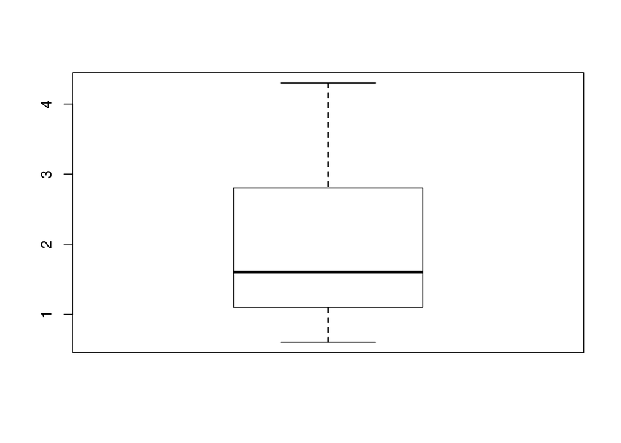

```r
#outlier확인

boxplot(dat3$price)
```

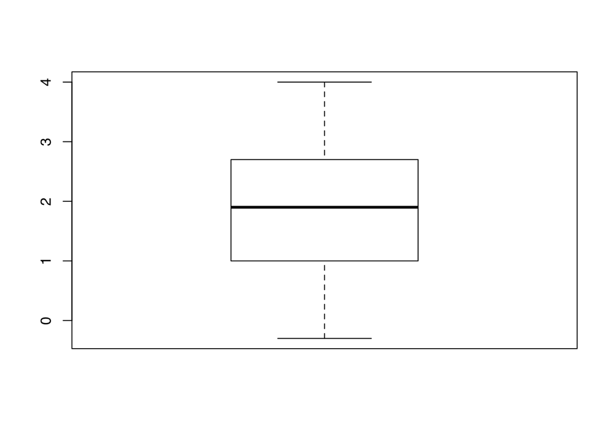

```r
boxplot(dat3$gdp)
```

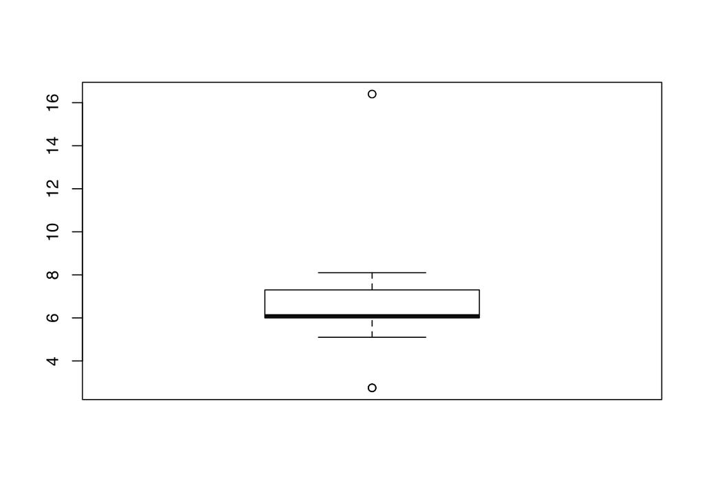

```r
boxplot(dat3$wage)
```

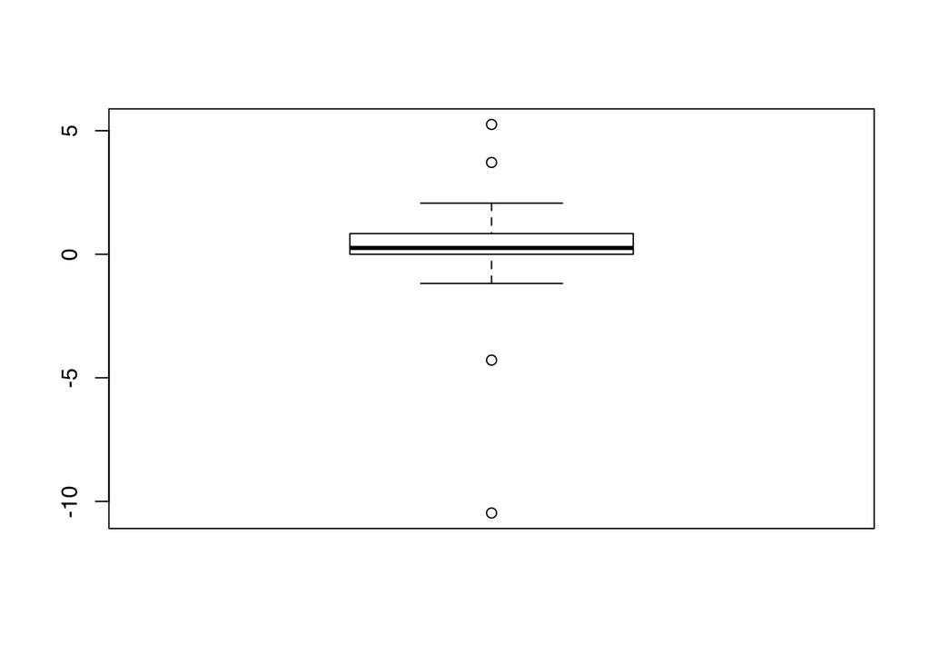

```r
boxplot(dat3$rent)
```

`boxplot()`함수를 이용해 `outlier`를 확인해보았다.  
물가, gdp deflator는 `outlter`가 존재하지 않았지만 **임대료**와 **최저임금**에는 `outlier`가 존재하였다.  
최저임금이 2018년 16.4% 인상됐는데 이 인상률은 이상치로 관측될만큼 높은 인상률임을 알 수 있었다. 임대료 또한 높은 증감률로 이상치가 관측되는 것이기 때문에 이 이상치들은 결측값이 아니므로 결측처리를 하지 않았다.

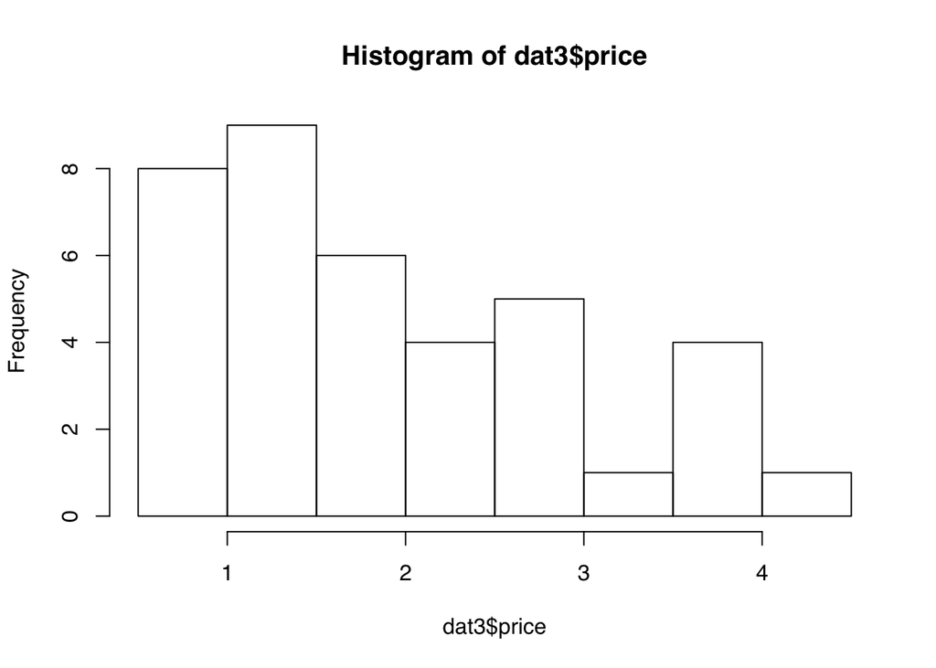

```r
#각 변수의 분포 확인
hist(dat3$price)
```

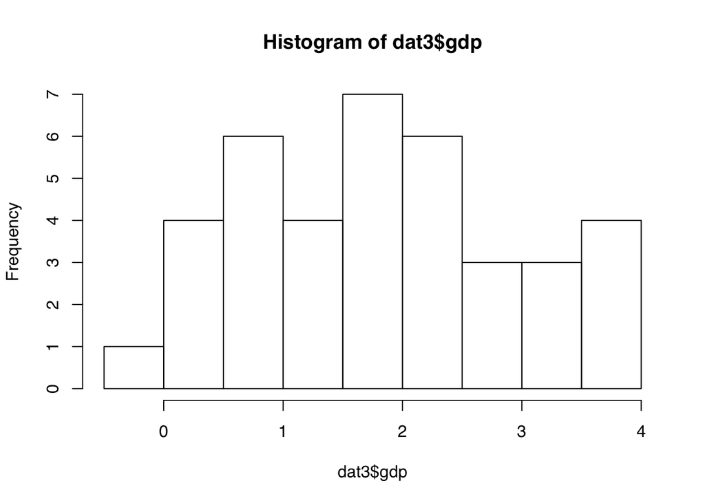

```r
hist(dat3$gdp)
```

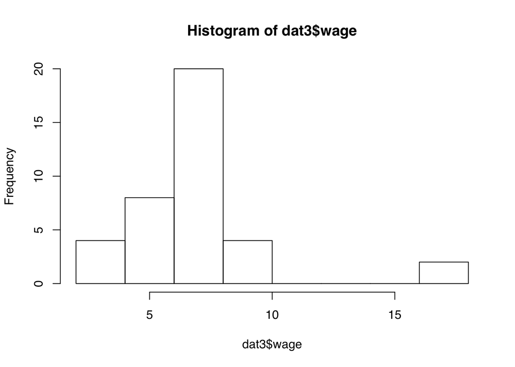

```r
hist(dat3$wage)
```

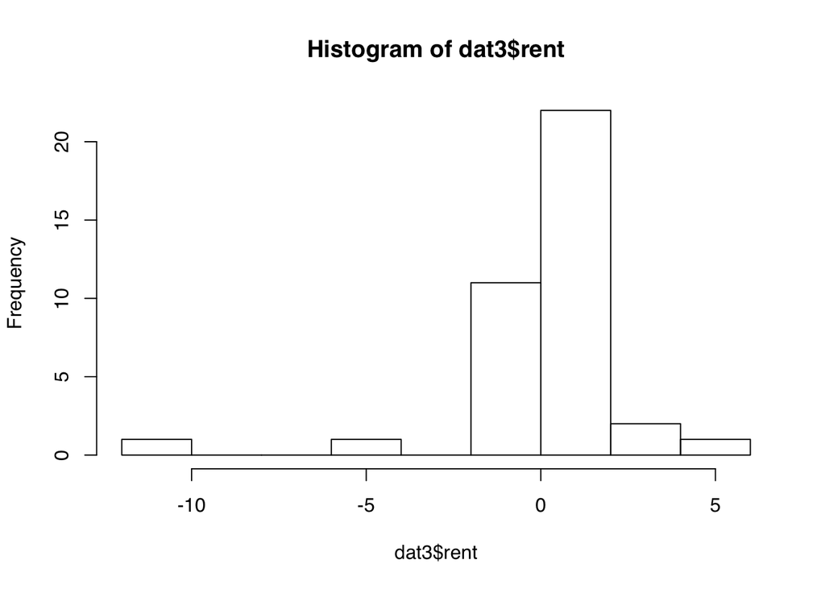

```r
hist(dat3$rent)
```

**각 변수들과 물가의 선형관계 시각화**

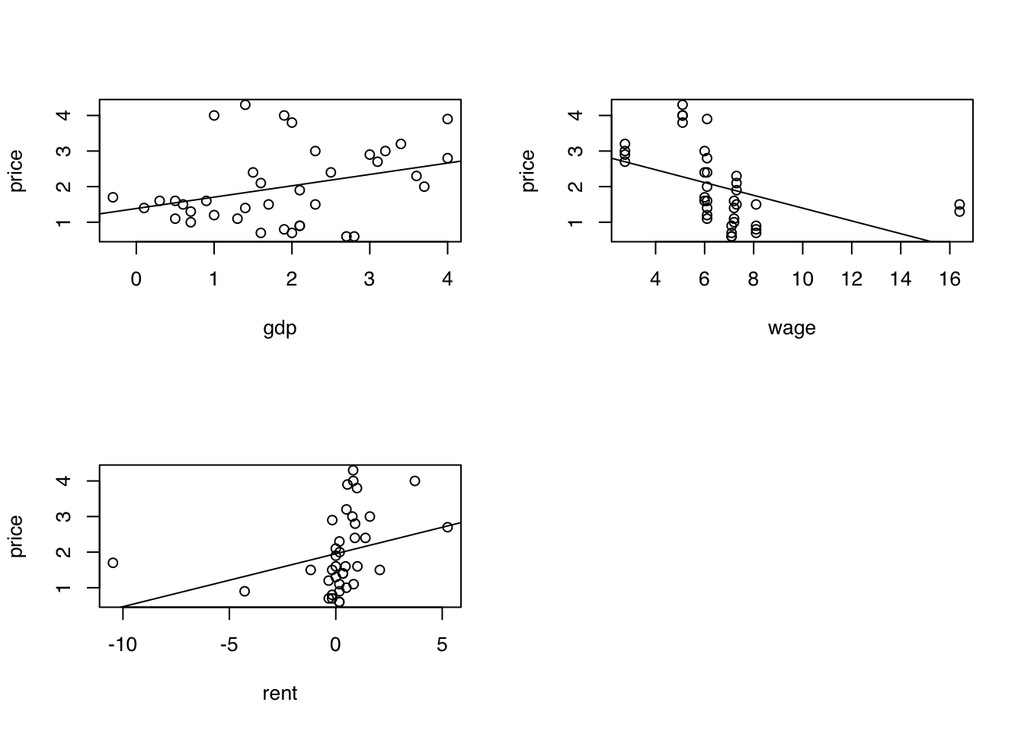

```r
par(mfrow=c(2,2))
plot(price~gdp,data =dat3)
abline(lm(price~gdp, dat3))
plot(price~wage,data =dat3)
abline(lm(price~wage, dat3))
plot(price~rent,data =dat3)
abline(lm(price~rent, dat3))
```

**각 변수들의 상관분석**

```r
fit1 <- lm(price ~ gdp, data=dat3)
summary(fit1)
```

```
##
## Call:
## lm(formula = price ~ gdp, data = dat3)
##
## Residuals:
##      Min       1Q   Median       3Q      Max
## -1.68017 -0.59884 -0.07519  0.50396  2.46713
##
## Coefficients:
##             Estimate Std. Error t value Pr(>|t|)
## (Intercept)   1.3856     0.3276   4.229 0.000154 ***
## gdp           0.3195     0.1505   2.124 0.040645 *
## ---
## Signif. codes:  0 '***' 0.001 '**' 0.01 '*' 0.05 '.' 0.1 ' ' 1
##
## Residual standard error: 1.029 on 36 degrees of freedom
## Multiple R-squared:  0.1113, Adjusted R-squared:  0.08664
## F-statistic:  4.51 on 1 and 36 DF,  p-value: 0.04065
```

```r
fit2 <- lm(price ~ wage, data=dat3)
summary(fit2)
```

```
##
## Call:
## lm(formula = price ~ wage, data = dat3)
##
## Residuals:
##     Min      1Q  Median      3Q     Max
## -1.3180 -0.8287 -0.1680  0.4796  2.0225
##
## Coefficients:
##             Estimate Std. Error t value Pr(>|t|)
## (Intercept)   3.1942     0.4235   7.542 6.47e-09 ***
## wage         -0.1797     0.0584  -3.078  0.00397 **
## ---
## Signif. codes:  0 '***' 0.001 '**' 0.01 '*' 0.05 '.' 0.1 ' ' 1
##
## Residual standard error: 0.9712 on 36 degrees of freedom
## Multiple R-squared:  0.2083, Adjusted R-squared:  0.1863
## F-statistic: 9.474 on 1 and 36 DF,  p-value: 0.003972
```

```r
fit3 <- lm(price ~ rent, data=dat3)
summary(fit3)
```

```
##
## Call:
## lm(formula = price ~ rent, data = dat3)
##
## Residuals:
##     Min      1Q  Median      3Q     Max
## -1.3794 -0.7481 -0.3171  0.7829  2.2241
##
## Coefficients:
##             Estimate Std. Error t value Pr(>|t|)
## (Intercept)  1.95483    0.16903  11.565 1.11e-13 ***
## rent         0.14869    0.07607   1.954   0.0584 .
## ---
## Signif. codes:  0 '***' 0.001 '**' 0.01 '*' 0.05 '.' 0.1 ' ' 1
##
## Residual standard error: 1.038 on 36 degrees of freedom
## Multiple R-squared:  0.09593,    Adjusted R-squared:  0.07082
## F-statistic:  3.82 on 1 and 36 DF,  p-value: 0.05844
```

각 변수들과 물가간의 상관관계는 위와 같다.  
* `gdp` 와 `price`의 상관관계를 살펴보면 p-value가 0.05보다 작으므로 유의하다고 할 수 있고, 0.32의 양의 상관도를 가진다. 이는 다른변수들이 고정되어 있는 상태에서 gdp가 1% 상승할 때 물가에 **0.3%** 영향을 미친다는 것을 알 수 있다.  
* 다음으로 `wage` 와 `price`의 상관관계를 살펴보면 p-value가 0.05보다 작으므로 유의하다고 할 수 있고, -0.18의 음의 상관도를 가진다. 이는 다른변수들이 고정되어 있는 상태에서 wage가 1% 상승할 때 물가에 **-0.18%** 영향을 미친다는 것을 알 수 있다.  
* 마지막으로 `rent` 와 `price`의 상관관계를 살펴보면 p-value가 0.05보다 크기 때문에 유의한 상관관계를 가진다고 할 수 없다.

**최저임금,gdp와 물가의 상관관계 비교 시각화**

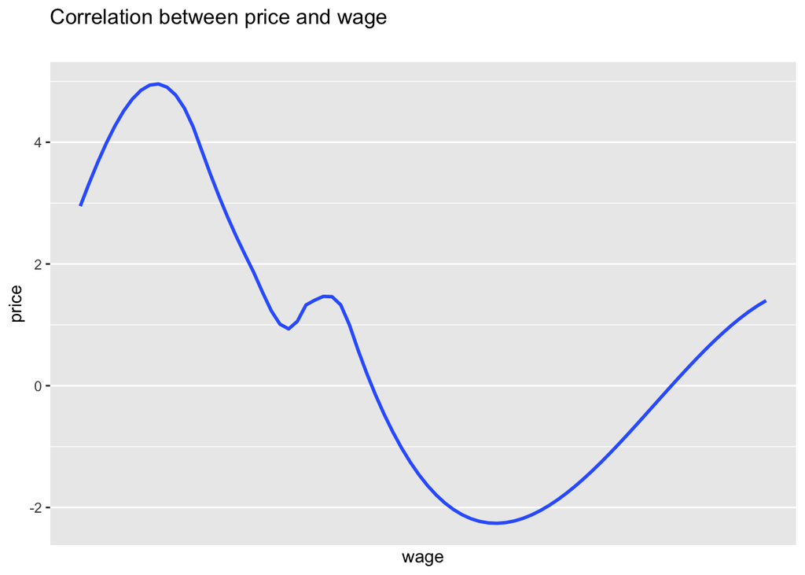

```r
gg1 <- ggplot(dat3, aes(x=wage, y=price)) +
  geom_smooth(method="loess", se=F) +
  labs(subtitle="",
       y="price",
       x="wage",
       title="Correlation between price and wage")+
  scale_x_discrete()

gg2 <- ggplot(dat3, aes(x=gdp, y=price)) +
  geom_smooth(method="loess", se=F) +
  labs(subtitle="",
       y="price",
       x="gdp",
       title="Correlation between price and gdp")+
  scale_x_discrete()

par(mfrow=c(2,1))
plot(gg1)
```

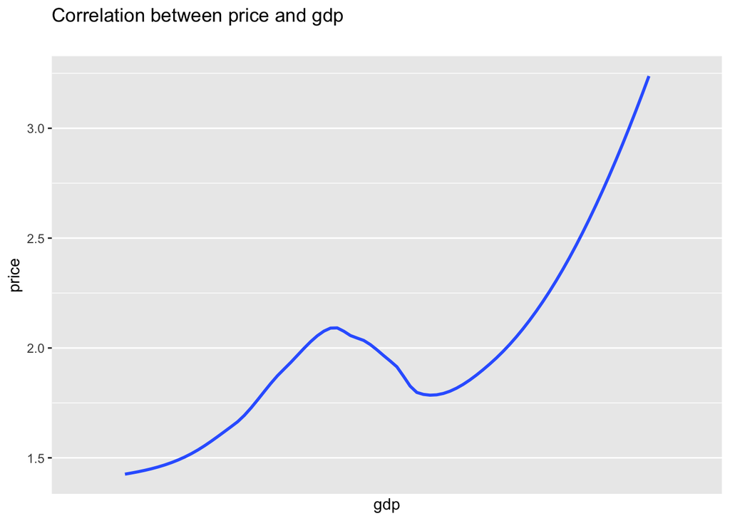

```r
plot(gg2)
```

`최저임금`,`gdp`와 `물가`의 상관관계를 비교 시각화 해보면 그 차이를 뚜렷하게 확인할 수 있다.  
앞에서 살펴보았던 상관계수로 예상해볼 수 있듯이 `gdp` 증감률과 `물가`의 증감률은 양의 관계를 가지는 그래프가 나타나지만, `최저임금`의 증감률은 **음의 상관관계**를 가지는 예상밖의 그래프가 나타난다.

**임대료와 공실률의 관계**

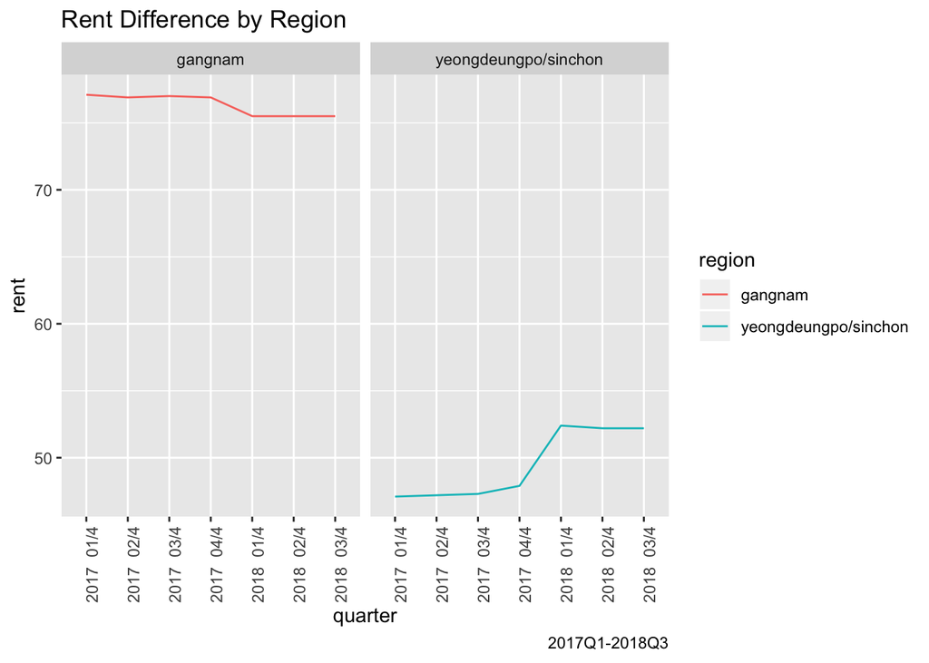

```r
rent_area <- read_xlsx("rent_area.xlsx")

rent_area1 <-rent_area %>% gather("quarter", "value", `2017년 01분기`:`2018년 03분기`)

rent_area1 <- rent_area1 %>% mutate(quarter = gsub("년"," ",rent_area1$quarter))
rent_area1 <- rent_area1 %>% mutate(quarter = gsub("분기","/4",rent_area1$quarter))

rent_area2<- rent_area1 %>%
  filter(X__1=="강남"|X__1=="영등포신촌")
rent_area2 <- rename(rent_area2,
                     지역=X__1)
rent_area2 <- rent_area2 %>%
  select(지역,quarter,value)

rent_area2$지역 <- gsub("강남","gangnam",rent_area2$지역)
rent_area2$지역 <- gsub("영등포신촌","yeongdeungpo/sinchon",rent_area2$지역)
rent_area2 <- rename(rent_area2,region=지역)

ggplot(data=rent_area2,aes(x=quarter,y=value,col=region,group=1))+
  geom_line()+ylab("rent")+
  theme(axis.text.x=element_text(angle=90)) +
  facet_wrap(~region)  +
  labs(title='Rent Difference by Region',
        caption="2017Q1-2018Q3")
```

꽤 유의한 수준으로 나올 것이라고 예상했던 `임대료`변수가 예상보다 낮은 유의성을 띄는 것으로 나타났다. 이에 `임대료`데이터와 여타 자료들을 살펴보았다.  
우선 데이터를 살펴보면 지역별로 임대료의 차이가 크고, 강남지역은 임대료가 하락하는 추세인 반면 영등포신촌지역은 임대료가 상승하는 추세이다.

- 한국감정원에 따르면 서울지역 **공실률**은 중대형 상가의 경우 지난해 1분기 6.5%에서 `꾸준히 상승`해서 올 1분기에는 7.7%로 1.2%p 올랐다가 2분기에 7.4%로 다소 주춤한 상황이다고 한다. 같은 기간 소규모 상가의 공실률은 2.9%에서 올 1분기 3.7%로 올랐다 2분기에 3.2%를 기록했으며 전국적인 상황 또한 큰 차이 없이 비슷한 흐름을 보이며 꾸준하게 공실률이 오르고 있다고 한다.
- 보통 임대료가 높을수록 공실률의 비율도 높아지는 경향이 있다. 위 그래프에 따르면 강남지역은 임대료가 낮아지는 추세이고 영등포신촌 지역은 임대료가 높아지는 추세이다. 이로 인해 영등포신촌의 공실률의 비율이 높아질 것을 예상할 수 있다.

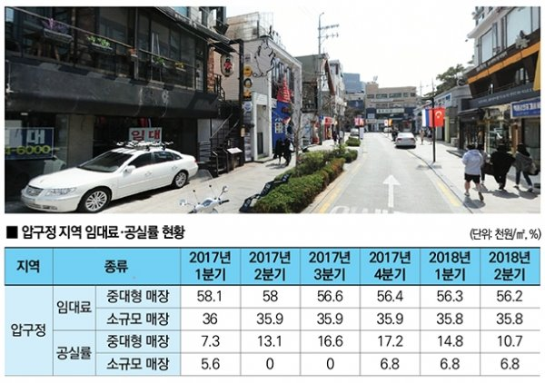

강남지역공실률

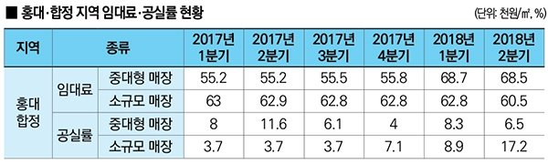

영등포신촌지역공실률

- 공실률데이터와 임대료 데이터를 함께 살펴보면 영등포신촌 지역은 중대형 상가보다 소규모 상가의 공실률 변화가 눈에 띈다. 중대형 상가의 공실률은 신촌이 전분기 대비 1.6%p 오른 6.8%를 기록했으며 이외 영등포(-3.6%p), 홍대합정(-1.8%p)은 다소 줄었다.  
  홍대합정 등 일부 지역에선 공실률이 높아지는데 임대료가 오히려 올라가는 상황이 발생되고 있는 것이다.  
  그 요인 중 하나는 `렌트 프리`이다. 렌트 프리란 공실률이 높아지는 가운데 임대료 하락을 막기 위해 무상임대를 하는 것이다.
- 위의 현상으로 미루어볼 때 실물경제에서 `높은임대료`가 `물가`에 독립변수로 작용하는 영향보다 `물가상승`으로 인한 상권붕괴, 그로 인한 `임대료 하락`이 보다 **직접적인 영향**을 미치고 있음을 알 수 있다.

**분기별 최저임금 증감률과 물가 증감률 비교 그래프**

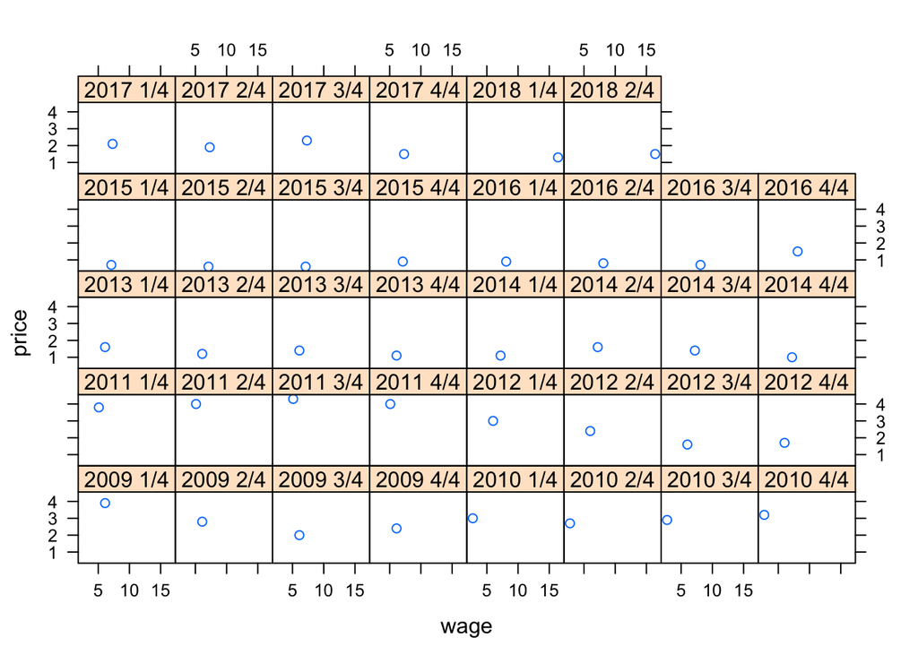

```r
plot1<-xyplot(price ~ wage | quarter, dat3)

plot1
```

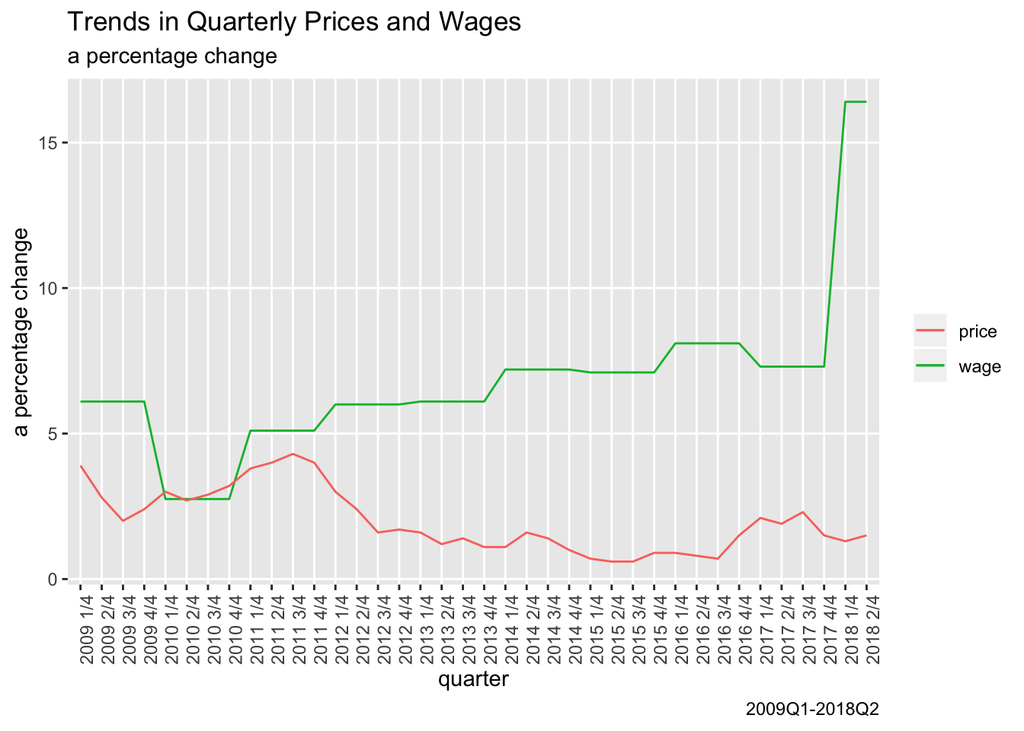

```r
plot2<-  ggplot(dat3, aes(x=quarter)) +
  geom_line(aes(y=wage, col="wage",group=1)) +
  geom_line(aes(y=price, col="price",group=1)) +
  theme(axis.text.x=element_text(angle=90)) +
  labs(title="Trends in Quarterly Prices and Wages",
       subtitle="a percentage change",
       caption="2009Q1-2018Q2", y="a percentage change") +
  scale_color_manual(name="",
                     values = c("wage"="#00ba38", "price"="#f8766d")) +
  theme(panel.grid.minor = element_blank())

plot2
```

마지막으로 **분기**에 따른 `최저임금증감률`과 `물가증감률` 그래프를 비교해보았다.

- 최저임금이 높은 인상률을 보이고 있지만 물가 비교적 낮은 인상률을 보인다. 또한 최저임금의 인상률과 상관없이 비슷한 양상을 띄고 있다.

**결론**

```
 결론적으로 최저임금 증감이 물가증감의 한 가지 유의미한 변수로 작용할 수는 있지만 최저임금이 단독변수로 물가에 막대한 영향을 미치지는 않는다.
 물가란 거시변수들을 포함한 여러 독립변수들의 다중작용에 의해 움직이기 때문에 현재 체감하고 있는 물가인상의 원인이 단순히 최저임금인상이라고는 볼 수 없다.
```